# FINAL PROJECT 1: LINEAR REGRESSION

### Proporsi Source dan Destination dari Uber vs Lyft

1. Filter kolom "Source" dan "Destination" dari data Uber dan Lyft

```python
dv41 = df_uber[['source','destination']]
dv42 = df_lyft[['source','destination']]
```

1. Memilih color palette untuk Uber dan Lyft

```python
colors1 = sns.color_palette("Spectral",12)
colors2 = sns.color_palette("rainbow",12)
```

1. Grouping dv41 dan dv42

```python
dv411 = dv41.groupby(['source'],as_index=True).agg({'source':'count'}, index=False)
dv412 = dv41.groupby(['destination'],as_index=True).agg({'source':'count'}, index=False)
dv413 = dv42.groupby(['source'],as_index=True).agg({'source':'count'}, index=False)
dv414 = dv42.groupby(['destination'],as_index=True).agg({'source':'count'}, index=False)
```

1. Membuat Data Visualization

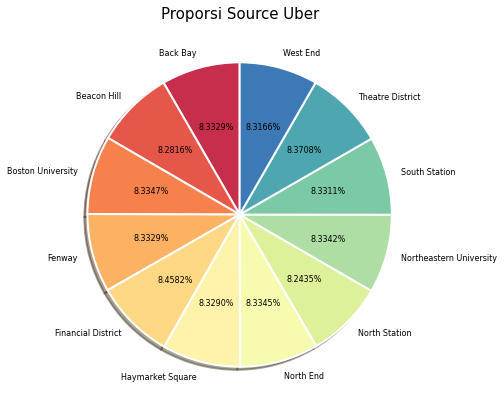

```python
dv411.plot(kind='pie',figsize=(12, 7),autopct='%1.4f%%',startangle=90,shadow=True,subplots=True,colors=colors1,
           textprops={'fontsize': 8},labels=dv411.index,legend=False,wedgeprops={'linewidth': 2.0, 'edgecolor': 'white'})
plt.title('Proporsi Source Uber', loc='center',size ='15')
plt.axis('off')
plt.show()
```

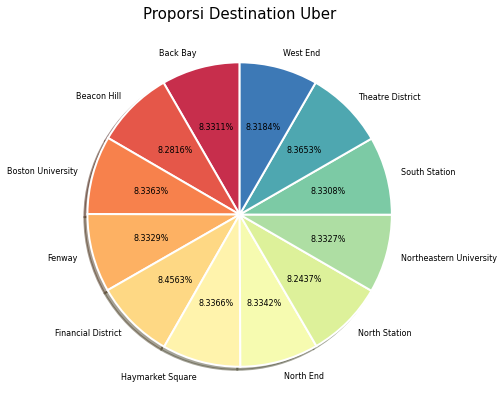

```python
dv412.plot(kind='pie',figsize=(12, 7),autopct='%1.4f%%',startangle=90,shadow=True,subplots=True,colors=colors1,
           textprops={'fontsize': 8},labels=dv411.index,legend=False,wedgeprops={'linewidth': 2.0, 'edgecolor': 'white'})
plt.title('Proporsi Destination Uber', loc='center',size ='15')
plt.axis('off')
plt.show()
```

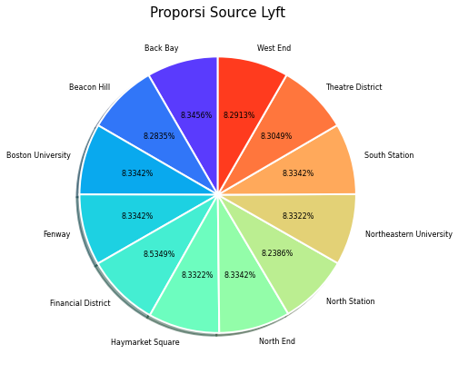

```python
dv413.plot(kind='pie',figsize=(12, 7),autopct='%1.4f%%',startangle=90,shadow=True,subplots=True,colors=colors2,
           textprops={'fontsize': 8},labels=dv411.index,legend=False,wedgeprops={'linewidth': 2.0, 'edgecolor': 'white'})
plt.title('Proporsi Source Lyft', loc='center',size ='15')
plt.axis('off')
plt.show()
```

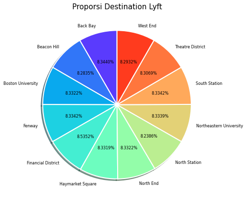

```python
dv414.plot(kind='pie',figsize=(12, 7),autopct='%1.4f%%',startangle=90,shadow=True,subplots=True,colors=colors2,
           textprops={'fontsize': 8},labels=dv411.index,legend=False,wedgeprops={'linewidth': 2.0, 'edgecolor': 'white'})
plt.title('Proporsi Destination Lyft', loc='center',size ='15')
plt.axis('off')
plt.show()
```

Dari visualisasi-visualisasi di atas, dapat kita lihat bahwa penggunaan jasa Uber dan Lyft sudah cukup merata (sekitar 8,2 - 8.5 %) karena proporsi antara daerah source dan destination tidak berbeda signifikan satu dengan yang lainnya.

### Distribusi dari Harga Uber vs Lyft

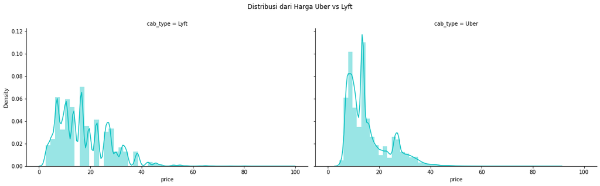

```python
grid1 = sns.FacetGrid(df, col='cab_type', height=5, aspect=1.6)
grid1.map(sns.distplot, 'price',bins=50, color = 'c')
plt.subplots_adjust(top=0.85)
grid1.fig.suptitle('Distribusi dari Harga Uber vs Lyft')
```

Selain menggunakan visualisasi di atas, digunakan juga Anderson Darling Test untuk menguji normalitas datanya agar didapatkan hasil yang lebih akurat

```python
# Performing the test on the Uber Price
p_value = normal_ad(df_uber['price'])[1]
print('p-value Uber Price from the test Anderson-Darling test below 0.05 generally means non-normal:', p_value)

# Reporting the normality of the Uber Price
if p_value < 0.05:
    print('Harga Uber tidak normally distributed','\n')
else:
    print('Harga Uber normally distributed','\n')

# Performing the test on the Lyft Price
p_value1 = normal_ad(df_lyft['price'])[1]
print('p-value Lyft Price from the test Anderson-Darling test below 0.05 generally means non-normal:', p_value1)

# Reporting the normality of the Lyft Price
if p_value1 < 0.05:
    print('Harga Lyft tidak normally distributed')
else:
    print('Harga Lyft normally distributed')
```

```
p-value Uber Price from the test Anderson-Darling test below 0.05 generally means non-normal: 0.0
Harga Uber tidak normally distributed

p-value Lyft Price from the test Anderson-Darling test below 0.05 generally means non-normal: 0.0
Harga Lyft tidak normally distributed
```

### Overall Correlations

1. Drop kolom yang tidak diperlukan

```python
df_cor = df.drop(['id','timestamp','day','month','datetime','timezone',
               'source','destination','cab_type','product_id','name',
               'latitude','longitude','apparentTemperature','precipProbability',
               'windGustTime','temperatureHighTime','temperatureLowTime',
               'apparentTemperatureHighTime','apparentTemperatureHighTime',
               'visibility.1','uvIndexTime','short_summary','long_summary',
               'icon','sunriseTime','sunsetTime','moonPhase',
               'temperatureMinTime','temperatureMaxTime','apparentTemperatureMax',
               'apparentTemperatureMaxTime','apparentTemperatureMinTime'], axis=1)
df_cor
```

|  | hour | price | distance | surge_multiplier | temperature | precipIntensity | humidity | windSpeed | windGust | visibility | ... | windBearing | cloudCover | uvIndex | ozone | precipIntensityMax | temperatureMin | temperatureMax | apparentTemperatureMin | hourGrouped | temperatureGrouped |
| --- | --- | --- | --- | --- | --- | --- | --- | --- | --- | --- | --- | --- | --- | --- | --- | --- | --- | --- | --- | --- | --- |
| 0 | 9 | 5.0 | 0.44 | 1.0 | 42.34 | 0.0000 | 0.68 | 8.66 | 9.17 | 10.000 | ... | 57 | 0.72 | 0 | 303.8 | 0.1276 | 39.89 | 43.68 | 33.73 | 07-09 | 40-45 |
| 1 | 2 | 11.0 | 0.44 | 1.0 | 43.58 | 0.1299 | 0.94 | 11.98 | 11.98 | 4.786 | ... | 90 | 1.00 | 0 | 291.1 | 0.1300 | 40.49 | 47.30 | 36.20 | 00-03 | 40-45 |
| 2 | 1 | 7.0 | 0.44 | 1.0 | 38.33 | 0.0000 | 0.75 | 7.33 | 7.33 | 10.000 | ... | 240 | 0.03 | 0 | 315.7 | 0.1064 | 35.36 | 47.55 | 31.04 | 00-03 | 35-40 |
| 3 | 4 | 26.0 | 0.44 | 1.0 | 34.38 | 0.0000 | 0.73 | 5.28 | 5.28 | 10.000 | ... | 310 | 0.00 | 0 | 291.1 | 0.0000 | 34.67 | 45.03 | 30.30 | 04-06 | 30-35 |
| 4 | 3 | 9.0 | 0.44 | 1.0 | 37.44 | 0.0000 | 0.70 | 9.14 | 9.14 | 10.000 | ... | 303 | 0.44 | 0 | 347.7 | 0.0001 | 33.10 | 42.18 | 29.11 | 00-03 | 35-40 |
| ... | ... | ... | ... | ... | ... | ... | ... | ... | ... | ... | ... | ... | ... | ... | ... | ... | ... | ... | ... | ... | ... |
| 693066 | 23 | 13.0 | 1.00 | 1.0 | 37.05 | 0.0000 | 0.74 | 2.34 | 2.87 | 9.785 | ... | 133 | 0.31 | 0 | 271.5 | 0.0000 | 31.42 | 44.76 | 27.77 | 22-24 | 35-40 |
| 693067 | 23 | 9.5 | 1.00 | 1.0 | 37.05 | 0.0000 | 0.74 | 2.34 | 2.87 | 9.785 | ... | 133 | 0.31 | 0 | 271.5 | 0.0000 | 31.42 | 44.76 | 27.77 | 22-24 | 35-40 |
| 693068 | 23 | 13.5 | 1.00 | 1.0 | 37.05 | 0.0000 | 0.74 | 2.34 | 2.87 | 9.785 | ... | 133 | 0.31 | 0 | 271.5 | 0.0000 | 31.42 | 44.76 | 27.77 | 22-24 | 35-40 |
| 693069 | 23 | 27.0 | 1.00 | 1.0 | 37.05 | 0.0000 | 0.74 | 2.34 | 2.87 | 9.785 | ... | 133 | 0.31 | 0 | 271.5 | 0.0000 | 31.42 | 44.76 | 27.77 | 22-24 | 35-40 |
| 693070 | 23 | 10.0 | 1.00 | 1.0 | 37.05 | 0.0000 | 0.74 | 2.34 | 2.87 | 9.785 | ... | 133 | 0.31 | 0 | 271.5 | 0.0000 | 31.42 | 44.76 | 27.77 | 22-24 | 35-40 |

693071 rows × 27 columns

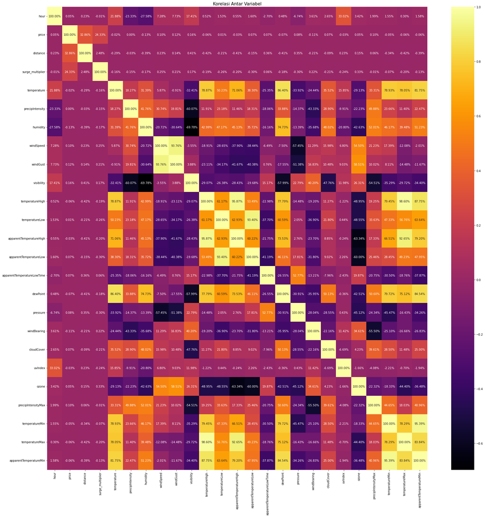

```python
fig, ax = plt.subplots(figsize=(30,30))
sns.heatmap(df_cor.corr(), annot=True, fmt='.2%',annot_kws={"size": 10},cmap="inferno")
plt.title("Korelasi Antar Variabel", loc='center',size ='15')
plt.show()
```

Berdasarkan heatmap di atas, korelasi variabel terkuat dengan variabel Price adalah Surge Multiplier dan Distance

## F. Data Preprocessing

Dataframe yang akan digunakan untuk permodelan Linear Regression nantinya adalah df1

```python
df1 = df[['price','distance','surge_multiplier','cab_type','name']]
df1
```

|  | price | distance | surge_multiplier | cab_type | name |
| --- | --- | --- | --- | --- | --- |
| 0 | 5.0 | 0.44 | 1.0 | Lyft | Shared |
| 1 | 11.0 | 0.44 | 1.0 | Lyft | Lux |
| 2 | 7.0 | 0.44 | 1.0 | Lyft | Lyft |
| 3 | 26.0 | 0.44 | 1.0 | Lyft | Lux Black XL |
| 4 | 9.0 | 0.44 | 1.0 | Lyft | Lyft XL |
| ... | ... | ... | ... | ... | ... |
| 693066 | 13.0 | 1.00 | 1.0 | Uber | UberXL |
| 693067 | 9.5 | 1.00 | 1.0 | Uber | UberX |
| 693068 | 13.5 | 1.00 | 1.0 | Uber | Taxi |
| 693069 | 27.0 | 1.00 | 1.0 | Uber | Black SUV |
| 693070 | 10.0 | 1.00 | 1.0 | Uber | UberPool |

693071 rows × 5 columns

### Encode Data

1. Menentukan kolom kategorikal yang akan di-encode

```python
cat_col = df1.select_dtypes(include=['object','category']).columns.tolist()
print(cat_col)
```

```
['cab_type', 'name']
```

1. Encode kolom kategorikal menggunakan One Hot Encoder

```python
for col in cat_col:
    encoder = OneHotEncoder(handle_unknown='ignore')
    enc_df = pd.DataFrame(encoder.fit_transform(df1[[col]]).toarray())
    enc_df.columns = encoder.get_feature_names([col])
    df1 = df1.drop(col, axis=1)
    df1 = pd.concat([df1, enc_df], axis=1)
```

1. Preview df1 setelah encode data

```python
df1
```

|  | price | distance | surge_multiplier | cab_type_Lyft | cab_type_Uber | name_Black | name_Black SUV | name_Lux | name_Lux Black | name_Lux Black XL | name_Lyft | name_Lyft XL | name_Shared | name_Taxi | name_UberPool | name_UberX | name_UberXL | name_WAV |
| --- | --- | --- | --- | --- | --- | --- | --- | --- | --- | --- | --- | --- | --- | --- | --- | --- | --- | --- |
| 0 | 5.0 | 0.44 | 1.0 | 1.0 | 0.0 | 0.0 | 0.0 | 0.0 | 0.0 | 0.0 | 0.0 | 0.0 | 1.0 | 0.0 | 0.0 | 0.0 | 0.0 | 0.0 |
| 1 | 11.0 | 0.44 | 1.0 | 1.0 | 0.0 | 0.0 | 0.0 | 1.0 | 0.0 | 0.0 | 0.0 | 0.0 | 0.0 | 0.0 | 0.0 | 0.0 | 0.0 | 0.0 |
| 2 | 7.0 | 0.44 | 1.0 | 1.0 | 0.0 | 0.0 | 0.0 | 0.0 | 0.0 | 0.0 | 1.0 | 0.0 | 0.0 | 0.0 | 0.0 | 0.0 | 0.0 | 0.0 |
| 3 | 26.0 | 0.44 | 1.0 | 1.0 | 0.0 | 0.0 | 0.0 | 0.0 | 0.0 | 1.0 | 0.0 | 0.0 | 0.0 | 0.0 | 0.0 | 0.0 | 0.0 | 0.0 |
| 4 | 9.0 | 0.44 | 1.0 | 1.0 | 0.0 | 0.0 | 0.0 | 0.0 | 0.0 | 0.0 | 0.0 | 1.0 | 0.0 | 0.0 | 0.0 | 0.0 | 0.0 | 0.0 |
| ... | ... | ... | ... | ... | ... | ... | ... | ... | ... | ... | ... | ... | ... | ... | ... | ... | ... | ... |
| 693066 | 13.0 | 1.00 | 1.0 | 0.0 | 1.0 | 0.0 | 0.0 | 0.0 | 0.0 | 0.0 | 0.0 | 0.0 | 0.0 | 0.0 | 0.0 | 0.0 | 1.0 | 0.0 |
| 693067 | 9.5 | 1.00 | 1.0 | 0.0 | 1.0 | 0.0 | 0.0 | 0.0 | 0.0 | 0.0 | 0.0 | 0.0 | 0.0 | 0.0 | 0.0 | 1.0 | 0.0 | 0.0 |
| 693068 | 13.5 | 1.00 | 1.0 | 0.0 | 1.0 | 0.0 | 0.0 | 0.0 | 0.0 | 0.0 | 0.0 | 0.0 | 0.0 | 1.0 | 0.0 | 0.0 | 0.0 | 0.0 |
| 693069 | 27.0 | 1.00 | 1.0 | 0.0 | 1.0 | 0.0 | 1.0 | 0.0 | 0.0 | 0.0 | 0.0 | 0.0 | 0.0 | 0.0 | 0.0 | 0.0 | 0.0 | 0.0 |
| 693070 | 10.0 | 1.00 | 1.0 | 0.0 | 1.0 | 0.0 | 0.0 | 0.0 | 0.0 | 0.0 | 0.0 | 0.0 | 0.0 | 0.0 | 1.0 | 0.0 | 0.0 | 0.0 |

693071 rows × 18 columns

### Split Data

Data yang akan digunakan untuk training adalah sebesar 75%, sedangkan 25% sisanya digunakan untuk testing

```python
train, test = train_test_split(df1, test_size=0.25, random_state=2)
train_index = train.index
test_index = test.index
```

```python
x_train = train.drop(['price'],axis=1)
y_train = train[['price']]
```

```python
x_test = test.drop(['price'],axis=1)
y_test = test[['price']]
```

### Scale Data

Proses standardization terhadap data train dan testing agar mean = 0 dan standar deviasi = 1

```python
scaler = StandardScaler()
x_train = scaler.fit_transform(x_train)
```

```python
x_test = scaler.transform(x_test)
```

## G. Pendefinisian dan Pelatihan Model

### Create and Fit Model

Model yang akan kita gunakan adalah Linear Regression dengan:

1. Dependent variable: Price
2. Independent variables: Cab Type, Name, Surge Multiplier, dan Distance

```python
lr = LinearRegression()
model = lr.fit(x_train, y_train)  #create model dari LR dari X dan y (berdasarkan data yang dimiliki)
```

## H. Evaluasi Model

### Get Results

Memperoleh hasil, intercept (konstanta), dan slope (koefisien independent variables)

```python
r_sq = model.score(x_train,y_train)
print('Coefficient of determination:',r_sq)
print('Intercept:',model.intercept_)
print('Slope:',model.coef_)
```

```
Coefficient of determination: 0.91784152269563
Intercept: [16.29724559]
Slope: [[ 2.90871711e+00  1.68007553e+00 -2.21755320e+12  1.28958259e+12
  -1.58114609e+12 -1.57943382e+12  3.18597766e+11  3.18472152e+11
   3.18014795e+11  3.18525451e+11  3.18996996e+11  3.18087270e+11
  -1.58116355e+12 -1.58063967e+12 -1.58159993e+12 -1.57827918e+12
  -1.57529959e+12]]
```

```python
model.coef_[0][12]
```

```
-1581163549068.1245
```

```python
model.coef_[0][13]
```

```
-1580639670825.4922
```

```python
model.coef_[0][16]
```

```
-1575299589469.0164
```

### Predict Response

Memprediksi data training menggunakan model regresi yang sudah ada

```python
y_pred = model.predict(x_train)
train['Estimated Y'] = np.round(y_pred,2)
train
```

|  | price | distance | surge_multiplier | cab_type_Lyft | cab_type_Uber | name_Black | name_Black SUV | name_Lux | name_Lux Black | name_Lux Black XL | name_Lyft | name_Lyft XL | name_Shared | name_Taxi | name_UberPool | name_UberX | name_UberXL | name_WAV | Estimated Y |
| --- | --- | --- | --- | --- | --- | --- | --- | --- | --- | --- | --- | --- | --- | --- | --- | --- | --- | --- | --- |
| 27838 | 22.5 | 2.04 | 1.0 | 1.0 | 0.0 | 0.0 | 0.0 | 0.0 | 1.0 | 0.0 | 0.0 | 0.0 | 0.0 | 0.0 | 0.0 | 0.0 | 0.0 | 0.0 | 21.98 |
| 571208 | 16.5 | 2.66 | 1.0 | 0.0 | 1.0 | 0.0 | 0.0 | 0.0 | 0.0 | 0.0 | 0.0 | 0.0 | 0.0 | 0.0 | 0.0 | 0.0 | 1.0 | 0.0 | 16.89 |
| 281888 | 10.5 | 3.06 | 1.0 | 1.0 | 0.0 | 0.0 | 0.0 | 0.0 | 0.0 | 0.0 | 1.0 | 0.0 | 0.0 | 0.0 | 0.0 | 0.0 | 0.0 | 0.0 | 11.14 |
| 431393 | 10.5 | 4.45 | 1.0 | 1.0 | 0.0 | 0.0 | 0.0 | 0.0 | 0.0 | 0.0 | 0.0 | 0.0 | 1.0 | 0.0 | 0.0 | 0.0 | 0.0 | 0.0 | 11.82 |
| 539045 | 7.0 | 1.20 | 1.0 | 0.0 | 1.0 | 0.0 | 0.0 | 0.0 | 0.0 | 0.0 | 0.0 | 0.0 | 0.0 | 0.0 | 1.0 | 0.0 | 0.0 | 0.0 | 6.23 |
| ... | ... | ... | ... | ... | ... | ... | ... | ... | ... | ... | ... | ... | ... | ... | ... | ... | ... | ... | ... |
| 84434 | 65.0 | 3.22 | 2.0 | 1.0 | 0.0 | 0.0 | 0.0 | 0.0 | 0.0 | 1.0 | 0.0 | 0.0 | 0.0 | 0.0 | 0.0 | 0.0 | 0.0 | 0.0 | 52.69 |
| 437782 | 18.5 | 3.06 | 1.0 | 0.0 | 1.0 | 0.0 | 0.0 | 0.0 | 0.0 | 0.0 | 0.0 | 0.0 | 0.0 | 0.0 | 0.0 | 0.0 | 1.0 | 0.0 | 17.91 |
| 620104 | 27.5 | 0.98 | 1.0 | 0.0 | 1.0 | 0.0 | 1.0 | 0.0 | 0.0 | 0.0 | 0.0 | 0.0 | 0.0 | 0.0 | 0.0 | 0.0 | 0.0 | 0.0 | 27.20 |
| 203245 | 10.0 | 1.45 | 1.0 | 0.0 | 1.0 | 0.0 | 0.0 | 0.0 | 0.0 | 0.0 | 0.0 | 0.0 | 0.0 | 0.0 | 1.0 | 0.0 | 0.0 | 0.0 | 6.87 |
| 100879 | 30.0 | 3.48 | 1.5 | 1.0 | 0.0 | 0.0 | 0.0 | 1.0 | 0.0 | 0.0 | 0.0 | 0.0 | 0.0 | 0.0 | 0.0 | 0.0 | 0.0 | 0.0 | 29.59 |

519803 rows × 19 columns

## I. Model Inference

### Predict Testing Data

Memprediksi testing data menggunakan model regresi yang sudah ada

```python
y_pred = model.predict(x_test)
test['Estimated Y'] = np.round(y_pred,2)
test
```

|  | price | distance | surge_multiplier | cab_type_Lyft | cab_type_Uber | name_Black | name_Black SUV | name_Lux | name_Lux Black | name_Lux Black XL | name_Lyft | name_Lyft XL | name_Shared | name_Taxi | name_UberPool | name_UberX | name_UberXL | name_WAV | Estimated Y |
| --- | --- | --- | --- | --- | --- | --- | --- | --- | --- | --- | --- | --- | --- | --- | --- | --- | --- | --- | --- |
| 434738 | 14.0 | 2.35 | 1.0 | 0.0 | 1.0 | 0.0 | 0.0 | 0.0 | 0.0 | 0.0 | 0.0 | 0.0 | 0.0 | 0.0 | 0.0 | 0.0 | 1.0 | 0.0 | 16.10 |
| 458961 | 34.0 | 4.78 | 1.0 | 1.0 | 0.0 | 0.0 | 0.0 | 0.0 | 1.0 | 0.0 | 0.0 | 0.0 | 0.0 | 0.0 | 0.0 | 0.0 | 0.0 | 0.0 | 28.98 |
| 615197 | 9.5 | 2.86 | 1.0 | 0.0 | 1.0 | 0.0 | 0.0 | 0.0 | 0.0 | 0.0 | 0.0 | 0.0 | 0.0 | 0.0 | 0.0 | 1.0 | 0.0 | 0.0 | 11.49 |
| 533697 | 13.5 | 1.00 | 1.0 | 0.0 | 1.0 | 0.0 | 0.0 | 0.0 | 0.0 | 0.0 | 0.0 | 0.0 | 0.0 | 1.0 | 0.0 | 0.0 | 0.0 | 0.0 | 10.45 |
| 284874 | 3.0 | 0.71 | 1.0 | 1.0 | 0.0 | 0.0 | 0.0 | 0.0 | 0.0 | 0.0 | 0.0 | 0.0 | 1.0 | 0.0 | 0.0 | 0.0 | 0.0 | 0.0 | 2.26 |
| ... | ... | ... | ... | ... | ... | ... | ... | ... | ... | ... | ... | ... | ... | ... | ... | ... | ... | ... | ... |
| 47343 | 33.5 | 2.84 | 1.0 | 0.0 | 1.0 | 0.0 | 1.0 | 0.0 | 0.0 | 0.0 | 0.0 | 0.0 | 0.0 | 0.0 | 0.0 | 0.0 | 0.0 | 0.0 | 31.95 |
| 365089 | 13.5 | 1.04 | 1.0 | 1.0 | 0.0 | 0.0 | 0.0 | 1.0 | 0.0 | 0.0 | 0.0 | 0.0 | 0.0 | 0.0 | 0.0 | 0.0 | 0.0 | 0.0 | 14.15 |
| 199581 | 7.0 | 3.08 | 1.0 | 1.0 | 0.0 | 0.0 | 0.0 | 0.0 | 0.0 | 0.0 | 0.0 | 0.0 | 1.0 | 0.0 | 0.0 | 0.0 | 0.0 | 0.0 | 8.32 |
| 375742 | 19.5 | 3.19 | 1.0 | 1.0 | 0.0 | 0.0 | 0.0 | 1.0 | 0.0 | 0.0 | 0.0 | 0.0 | 0.0 | 0.0 | 0.0 | 0.0 | 0.0 | 0.0 | 19.64 |
| 402867 | 16.5 | 1.48 | 1.0 | 1.0 | 0.0 | 0.0 | 0.0 | 1.0 | 0.0 | 0.0 | 0.0 | 0.0 | 0.0 | 0.0 | 0.0 | 0.0 | 0.0 | 0.0 | 15.27 |

173268 rows × 19 columns

```python
model.score(x_test, y_test)
```

```
0.9188741580400912
```

### Comparison between Testing Data and Training Data

Membandingkan model score antara testing data dan training data

```python
compared = pd.DataFrame({'Keterangan':['Training Data','Testing Data'],'Tingkat Akurasi':[model.score(x_train,y_train), model.score(x_test, y_test)]})
compared
```

|  | Keterangan | Tingkat Akurasi |
| --- | --- | --- |
| 0 | Training Data | 0.917842 |
| 1 | Testing Data | 0.918874 |

## K. Pengambilan Kesimpulan

Berdasarkan pemaparan di atas, model regresi yang tepat untuk data ini adalah Linear Regression dengan independent variables:

1. distance (x1)
2. surge_multiplier (x2)
3. cab_type_Lyft (x3)
4. cab_type_Uber (x4)
5. name_Black (x5)
6. name_Black SUV (x6)
7. name_Lux (x7)
8. name_Lux Black (x8)
9. name_Lux Black XL (x9)
10. name_Lyft (x10)
11. name_Lyft XL (x11)
12. name_Shared (x12)
13. name_Taxi (x13)
14. name_UberPool (x14)
15. name_UberX (x15)
16. name_UberXL (x16)
17. name_WAV (x17)

Dengan dependent variblenya:

1. price (y)

[output not shown]